# Reproducible Research - Assignment Week 2

Simone Krämer

24 September 2017

## Loading and preprocessing the data

1. Load the data  
   Check if the data was already downloaded to the working directory. If not, download it…

```r
url <- "https://d396qusza40orc.cloudfront.net/repdata%2Fdata%2Factivity.zip"
if (!file.exists("PersonalMovementData.zip"))
{
    download.file(url,
                  destfile='PersonalMovementData.zip',
                  mode="wb")
}

if (!dir.exists("./PersonalMovementData"))
{
    unzip(zipfile = "PersonalMovementData.zip",
          exdir = "./PersonalMovementData")
}
```

… then it can be loaded into R:

```r
data <- read.csv("./PersonalMovementData/activity.csv")
```

2. Process/transform the data (if necessary) into a format suitable for your analysis

```r
data$date <- as.Date(data$date, "%Y-%m-%d")
```

## What is mean total number of steps taken per day?

In this first analysis, missing data will be ignored.

1. Calculate the total number of steps taken per day

```r
numStepsDay <- aggregate(data$steps, by = list(data$date), FUN = sum, na.rm = TRUE)
colnames(numStepsDay) <- c("day", "numberOfSteps")
print(numStepsDay)
```

```
##           day numberOfSteps
## 1  2012-10-01             0
## 2  2012-10-02           126
## 3  2012-10-03         11352
## 4  2012-10-04         12116
## 5  2012-10-05         13294
## 6  2012-10-06         15420
## 7  2012-10-07         11015
## 8  2012-10-08             0
## 9  2012-10-09         12811
## 10 2012-10-10          9900
## 11 2012-10-11         10304
## 12 2012-10-12         17382
## 13 2012-10-13         12426
## 14 2012-10-14         15098
```

[output cut: 47 more lines]

2. Histogram of the total number of steps taken each day

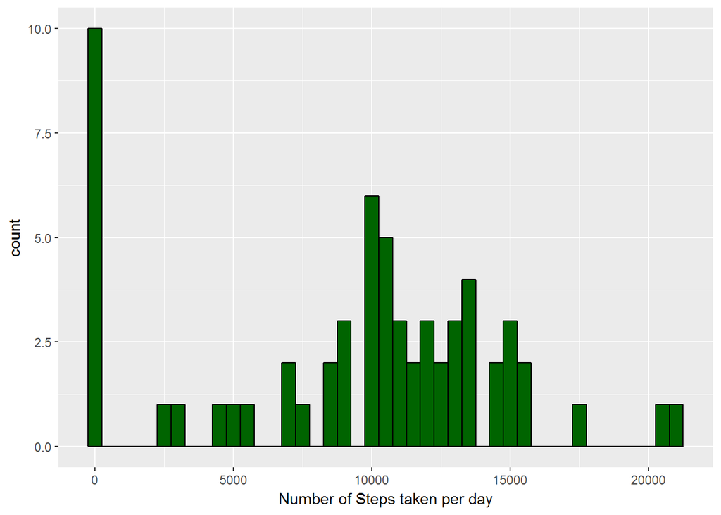

```r
library(ggplot2)
qplot(numStepsDay$numberOfSteps, geom = "histogram", binwidth = 500,
      xlab = "Number of Steps taken per day", fill=I("darkgreen"),
      col=I("black"))
```

3. Calculate and report the mean and median of the total number of steps taken per day

```r
meanNumStepsDay <- mean(numStepsDay$numberOfSteps, na.rm = TRUE)
medianNumStepsDay <- median(numStepsDay$numberOfSteps, na.rm = TRUE)
```

The mean value of steps taken per day is 9354; the median value is 10395.

## What is the average daily activity pattern?

1. Time series plot of the 5-minute interval and the average number of steps taken, averaged across all days

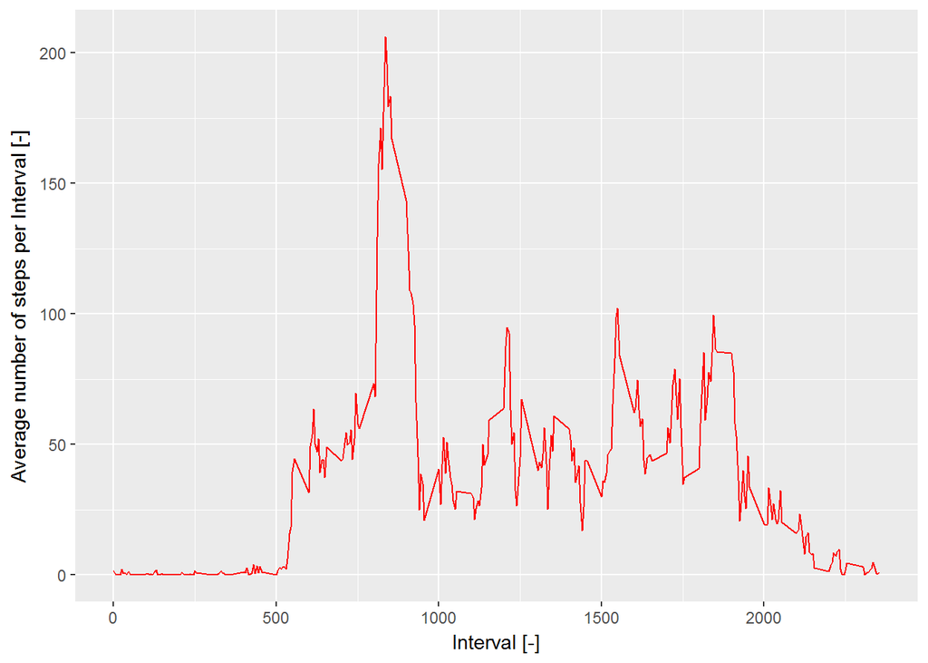

```r
meanStepsInterval <- aggregate(data$steps, by = list(data$interval), FUN = mean, na.rm = TRUE)
colnames(meanStepsInterval) <- c("interval", "meanNumberOfSteps")

library(ggplot2)
g <- ggplot(meanStepsInterval, aes(meanStepsInterval$interval, meanStepsInterval$meanNumberOfSteps))
g + geom_line(colour = 'red') + labs(x = "Interval [-]", y = "Average number of steps per Interval [-]")
```

2. Which 5-minute interval, on average across all the days in the dataset, contains the maximum number of steps?

```r
maxMeanStepsInterval <- max(meanStepsInterval$meanNumberOfSteps, na.rm = TRUE)
interval <- meanStepsInterval[meanStepsInterval$meanNumberOfSteps == maxMeanStepsInterval,]$interval
```

The interval which has the highest number of steps averaged across all the days is `835`.

# Imputing missing values

1. Calculate and report the total number of missing values in the dataset (i.e. the total number of rows with NAs)

```r
totalnumberNA <- sum(is.na(data$steps))
```

The number of missing values in the dataset is `2304`.

2. Devise a strategy for filling in all of the missing values in the dataset.  
   Assumption: If there is no data available for that interval, it will take the mean value for that interval. So first, generate data with replacement data for all missing values

```r
library(plyr)
indNA <- which(!complete.cases(data$steps))
dataNA <- data[indNA,]
dataFilledNA <- join(dataNA, meanStepsInterval, by = "interval")
dataFilledNA <- dataFilledNA[, c("interval", "date", "meanNumberOfSteps")]
colnames(dataFilledNA) <- c("interval", "date", "steps")
```

3. Create a new dataset that is equal to the original dataset but with the missing data filled in.

```r
dataComplete <- data[which(complete.cases(data$steps)),]
dataComplete <- rbind(dataComplete, dataFilledNA)
dataComplete <- dataComplete[order(dataComplete$date, dataComplete$interval), ]
```

4. Histogram of the total number of steps taken each day

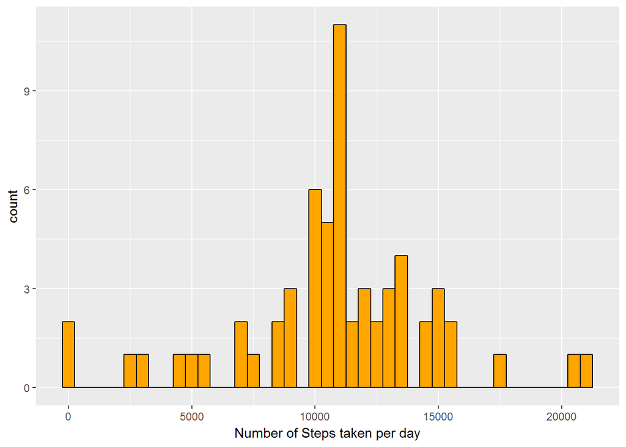

```r
library(ggplot2)
numStepsDay <- aggregate(dataComplete$steps, by = list(dataComplete$date), FUN = sum, na.rm = TRUE)
colnames(numStepsDay) <- c("day", "numberOfSteps")

qplot(numStepsDay$numberOfSteps, geom = "histogram", binwidth = 500,
      xlab = "Number of Steps taken per day", fill=I("orange"),
      col=I("black"))
```

```r
meanNumStepsDay <- mean(numStepsDay$numberOfSteps, na.rm = TRUE)
medianNumStepsDay <- median(numStepsDay$numberOfSteps, na.rm = TRUE)
```

## Are there differences in activity patterns between weekdays and weekends?

1. Create a new factor variable in the dataset with two levels - “weekday” and “weekend” indicating whether a given date is a weekday or weekend day.

```r
library(dplyr)
weekdays <- c("Montag", "Dienstag", "Mittwoch", "Donnerstag", "Freitag")
dataComplete <- mutate(dataComplete, dayType = factor((weekdays(dataComplete$date) %in% weekdays),
                       levels=c(FALSE, TRUE), labels=c('weekend', 'weekday')))
```

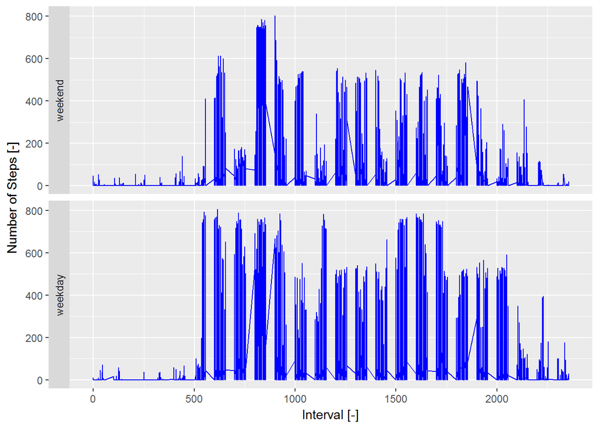

```r
meanStepsDayType <- aggregate(dataComplete$steps, by = list(dataComplete$interval,
                                                            dataComplete$dayType),
                              FUN = mean, na.rm = TRUE)
colnames(meanStepsDayType) <- c("interval", "dayType", "meanNumberOfSteps")

library(ggplot2)
g <- ggplot(dataComplete, aes(dataComplete$interval, dataComplete$steps))
g + geom_line(colour = 'blue') +
    labs(x = "Interval [-]", y = "Number of Steps [-]") +
    facet_grid(dayType ~ ., switch = "y")
```